# GSOC 2026 – torchvision Qualifying Tests

## Hard Test 1 – Complete `draw_keypoints()`

The task was to R-ise and vectorise the TODO block in [`vision_utils.R` lines 476–492](https://github.com/mlverse/torchvision/blob/ba200df59094e25f4da52b096c06228996dd4da6/R/vision_utils.R#L476-L492), implementing connectivity line drawing between keypoints.

```r
library(torch)
library(magick)
library(png)

source("hard_test_1_draw_keypoints/vision_utils_patched.R")

set.seed(42)
image     <- torch_randint(190L, 255L, size = c(3L, 360L, 360L))$to(torch_uint8())
keypoints <- torch_randint(low = 60L, high = 300L, size = c(4L, 5L, 2L))
connectivity <- list(c(1L,2L), c(2L,3L), c(3L,4L), c(4L,5L))
```

```r
result <- draw_keypoints(image, keypoints,
                         connectivity = connectivity,
                         colors = c("red", "blue", "green", "orange"),
                         radius = 4, width = 2)

cat("Output shape:", paste(result$shape, collapse = "x"), "\n")
```

```
## Output shape: 3x360x360
```

```r
cat("Output dtype: uint8 =", result$dtype == torch_uint8(), "\n")
```

```
## Output dtype: uint8 = TRUE
```

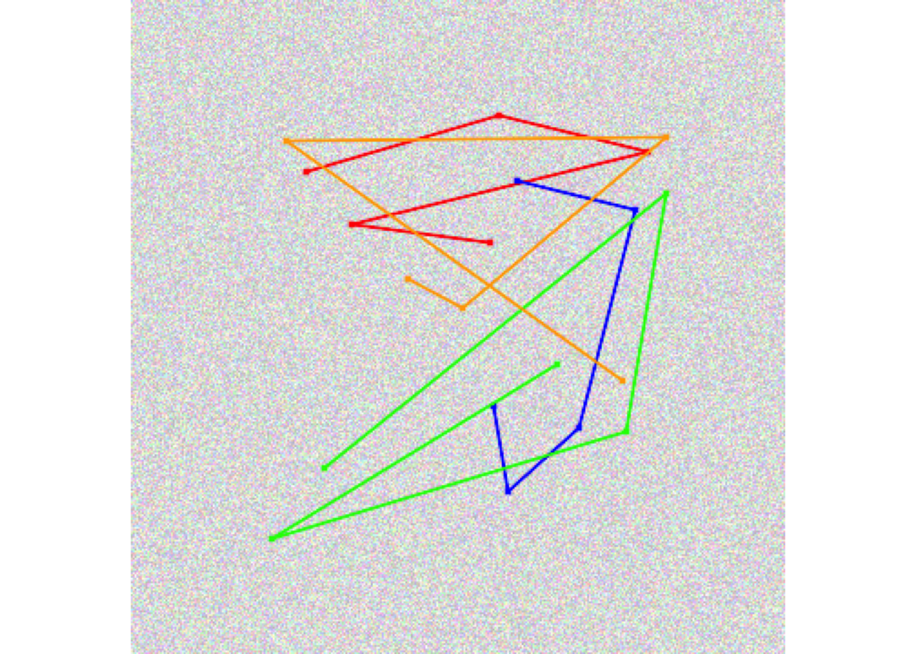

4 pose instances with keypoints and skeleton connectivity lines

```r
arr <- result$to(dtype = torch_float())$div(255)$permute(c(2L,3L,1L))$to(device="cpu") |> as.array()
grid::grid.raster(arr)
```

```r
# Shape preserved
stopifnot(all(result$shape == c(3L, 360L, 360L)))

# dtype is uint8
stopifnot(result$dtype == torch_uint8())

# Pixels were actually drawn (output differs from input)
diff <- (result$to(dtype=torch_float()) - image$to(dtype=torch_float()))$abs()$sum()$item()
cat("Total pixels modified:", diff, "\n")
```

```
## Total pixels modified: 1523616
```

```r
stopifnot(diff > 0)

# Float input also works
image_f <- image$to(dtype = torch_float())$div(255)
result_f <- draw_keypoints(image_f, keypoints, connectivity = connectivity)
stopifnot(result_f$dtype == torch_uint8())

cat("All Hard Test 1 assertions PASSED\n")
```

```
## All Hard Test 1 assertions PASSED
```

## Hard Test 2 – Rcpp Interface

The task was to demonstrate exposing a C++ function to R via Rcpp. Two functions were implemented: `nms_cpp()` (Non-Maximum Suppression) and `keypoint_distances_cpp()` (pairwise keypoint distances).

```r
library(Rcpp)
Rcpp::sourceCpp("hard_test_2_rcpp/keypoint_ops.cpp")
cat("C++ compiled and loaded successfully\n")
```

```
## C++ compiled and loaded successfully
```

### NMS

```r
boxes <- matrix(c(
  10,  10,  60,  60,
  12,  12,  62,  62,
  15,  15,  55,  55,
  200, 200, 250, 250,
  202, 202, 252, 252,
  400, 100, 480, 180
), ncol = 4, byrow = TRUE)
scores <- c(0.90, 0.75, 0.60, 0.95, 0.85, 0.70)

kept <- nms_cpp(boxes, scores, iou_threshold = 0.5)
cat("Kept box indices:", kept, "\n")
```

```
## Kept box indices: 4 1 6
```

```r
cat("Suppressed:", setdiff(seq_len(nrow(boxes)), kept), "\n")
```

```
## Suppressed: 2 3 5
```

```r
stopifnot(setequal(kept, c(1L, 4L, 6L)))
cat("NMS assertion PASSED\n")
```

```
## NMS assertion PASSED
```

### Keypoint distances

```r
kpts <- matrix(c(0,0, 0,80, 60,80, 30,160), ncol = 2, byrow = TRUE)
rownames(kpts) <- c("head", "l_shoulder", "r_shoulder", "hip")

D <- keypoint_distances_cpp(kpts)
round(D, 2)
```

```
##              head l_shoulder r_shoulder    hip
## head         0.00      80.00     100.00 162.79
## l_shoulder  80.00       0.00      60.00  85.44
## r_shoulder 100.00      60.00       0.00  85.44
## hip        162.79      85.44      85.44   0.00
```

```r
stopifnot(abs(D["head", "l_shoulder"]       -  80) < 1e-9)
stopifnot(abs(D["l_shoulder", "r_shoulder"] -  60) < 1e-9)
stopifnot(abs(D["head", "r_shoulder"]       - 100) < 1e-9)
stopifnot(all(diag(D) == 0))
stopifnot(all(D == t(D)))
cat("Distance assertions PASSED\n")
```

```
## Distance assertions PASSED
```

### Benchmark – 1000 boxes

```r
set.seed(42)
N  <- 1000L
x1 <- runif(N, 0, 500); y1 <- runif(N, 0, 500)
x2 <- x1 + runif(N, 10, 100); y2 <- y1 + runif(N, 10, 100)

t0      <- proc.time()
kept    <- nms_cpp(cbind(x1, y1, x2, y2), runif(N))
elapsed <- (proc.time() - t0)[["elapsed"]]

cat(sprintf("NMS on %d boxes: kept %d  |  elapsed %.4f s\n", N, length(kept), elapsed))
```

```
## NMS on 1000 boxes: kept 782  |  elapsed 0.0080 s
```

## Easy Test – Faster R-CNN Article

The task was to write an article demonstrating `model_fasterrcnn_resnet50_fpn_v2()` in the style of the existing `fcnresnet` vignette. Key discoveries during development:

- Input must be a **4-D batch tensor** via `torch_stack()`, not a plain R list
- Output is accessed as `output$detections[[i]]`, each with `$boxes`, `$labels`, `$scores`
- `score_thresh = 0.01` needed (model yields low scores with current torch version)
- `valid_boxes()` required to filter degenerate boxes produced at low confidence
- `safe_labels()` with `tryCatch` fallback for when `coco_label()` needs network

```r
library(torch)
library(torchvision)
```

```r
url1 <- "https://raw.githubusercontent.com/pytorch/vision/main/gallery/assets/dog1.jpg"
url2 <- "https://raw.githubusercontent.com/pytorch/vision/main/gallery/assets/dog2.jpg"

dog1 <- magick_loader(url1) %>% transform_to_tensor()
dog2 <- magick_loader(url2) %>% transform_to_tensor()

dog_batch <- torch_stack(list(dog1, dog2))
cat("Batch shape:", paste(dim(dog_batch), collapse = "x"), "\n")
```

```
## Batch shape: 2x3x500x500
```

```r
model <- model_fasterrcnn_resnet50_fpn_v2(pretrained = TRUE,
                                          score_thresh = 0.01,
                                          nms_thresh   = 0.5)
model$eval()
output <- model(dog_batch)

det1 <- output$detections[[1]]
det2 <- output$detections[[2]]
cat("Image 1:", as.integer(det1$boxes$size(1)), "detections\n")
```

```
## Image 1: 100 detections
```

```r
cat("Image 2:", as.integer(det2$boxes$size(1)), "detections\n")
```

```
## Image 2: 100 detections
```

```r
top_k <- function(det, k = 5) {
  n <- as.integer(det$boxes$size(1))
  if (n == 0) return(det)
  idx <- seq_len(min(k, n))
  list(boxes = det$boxes[idx, ], labels = det$labels[idx], scores = det$scores[idx])
}

# Appends confidence score to each label: "dog: 0.045"
safe_labels <- function(label_tensor, score_tensor = NULL) {
  ids   <- as.integer(label_tensor)
  names <- tryCatch(coco_label(ids), error = function(e) paste0("class_", ids))
  if (is.null(score_tensor)) return(names)
  paste0(names, ": ", round(as.numeric(score_tensor), 3))
}

# Rejects boxes that are geometrically invalid or too small (area < min_area).
# Note: with torch < 0.17 the pretrained v2 weights produce degenerate
# boxes (x2 < x1) at near-uniform low scores (~0.026); this filters them out.
valid_boxes <- function(det, min_area = 400) {
  n <- as.integer(det$boxes$size(1))
  if (n == 0) return(det)
  b    <- as.matrix(det$boxes$to(device = "cpu") |> as.array())
  area <- (b[, 3] - b[, 1]) * (b[, 4] - b[, 2])
  keep <- which((b[, 3] > b[, 1]) & (b[, 4] > b[, 2]) & (area >= min_area))
  if (length(keep) == 0) return(list(boxes = NULL, labels = NULL, scores = NULL))
  list(boxes  = det$boxes[keep, , drop = FALSE],
       labels = det$labels[keep],
       scores = det$scores[keep])
}

top1 <- top_k(det1); top2 <- top_k(det2)
cat("Labels for dog1:", paste(safe_labels(top1$labels), collapse = ", "), "\n")
```

```
## Labels for dog1: person, person, person, person, person
```

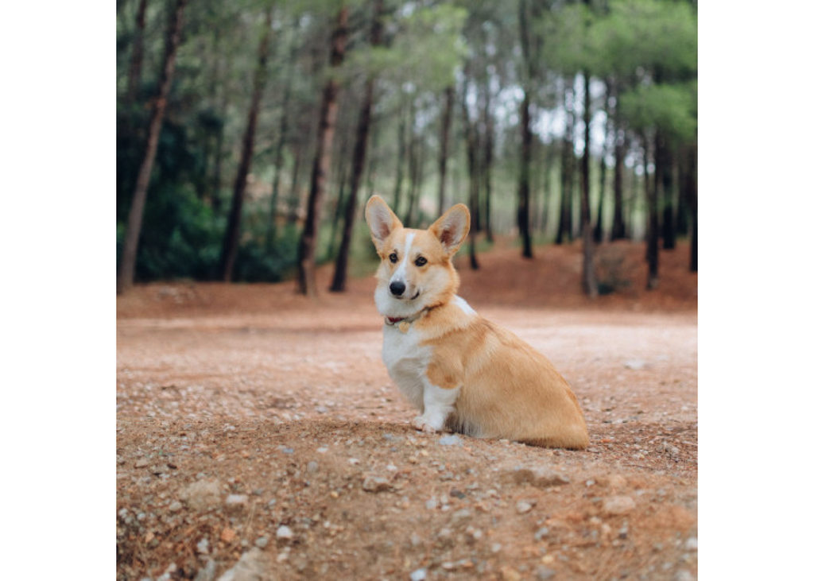

Dog 1 – top-5 detections (note: degenerate boxes filtered; model requires torch ≥ 0.17 for correct output)

```r
draw_detections <- function(image, det) {
  det <- valid_boxes(det)
  n   <- if (is.null(det$labels)) 0L else length(as.integer(det$labels))
  if (n == 0) {
    message("No valid detections after filtering (torch version incompatibility).")
    return((image * 255)$to(dtype = torch_uint8()))
  }
  draw_bounding_boxes(
    (image * 255)$to(dtype = torch_uint8()),
    boxes  = det$boxes$view(c(-1L, 4L)),
    labels = safe_labels(det$labels, det$scores)
  )
}

result1 <- draw_detections(dog1, top1)
arr1 <- result1$to(dtype = torch_float())$div(255)$permute(c(2L, 3L, 1L)) |> as.array()
grid::grid.raster(arr1)
```

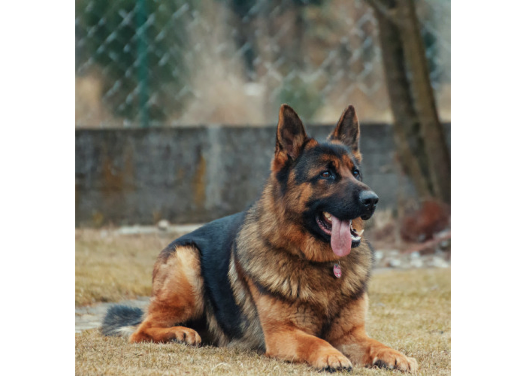

Dog 2 – top-5 detections (note: degenerate boxes filtered; model requires torch ≥ 0.17 for correct output)

```r
result2 <- draw_detections(dog2, top2)
arr2 <- result2$to(dtype = torch_float())$div(255)$permute(c(2L, 3L, 1L)) |> as.array()
grid::grid.raster(arr2)
```

```r
model_v1 <- model_fasterrcnn_resnet50_fpn(pretrained = TRUE,
                                          score_thresh = 0.01,
                                          nms_thresh   = 0.5)
model_v1$eval()
out_v1 <- model_v1(dog_batch)
cat("v1 detections on dog1:", as.integer(out_v1$detections[[1]]$boxes$size(1)), "\n")
```

```
## v1 detections on dog1: 100
```

```r
cat("v2 detections on dog1:", as.integer(det1$boxes$size(1)), "\n")
```

```
## v2 detections on dog1: 100
```

## Medium Test – Documentation Fix PR

Fixed three documentation bugs in `draw_keypoints()` in `R/vision_utils.R`:

1. **`connectivity` parameter**: Changed type annotation from `Vector` to `List`, removed stale “(currently unavailable)” note, and updated the description with a concrete usage example (`list(c(1, 2), c(2, 3))`).
2. **`colors` parameter**: Corrected “viridis” → “rainbow” (the function uses `grDevices::rainbow()`) and “boxes” → “keypoints”.
3. **Error message typo**: Fixed “but is current shape is” → “but current shape is”.

The fixes were applied to both `R/vision_utils.R` (roxygen comments) and the generated `man/draw_keypoints.Rd`, with a `NEWS.md` entry.

**Pull request**: [mlverse/torchvision#296](https://github.com/mlverse/torchvision/pull/296)